# Rgroup Project

## Project instructions

### Introduction

```r
#install.packages("fmsb")
#install.packages("PerformanceAnalytics")
#install.packages("textdata")
#install.packages("tidytext")
#install.packages("devtools")
#install.packages('inspectdf')
library(fmsb)
library(ggplot2)
library(inspectdf)
library(dplyr)
library(PerformanceAnalytics)
library(tidytext)
library(tidyverse)
```

```r
album_songs <- taylor::taylor_album_songs
all_songs <- as.data.frame(taylor::taylor_all_songs)
albums <- as.data.frame(taylor::taylor_albums)
```

### Data Cleaning and Restructuring

##### Numerical Data

```r
num<-which(sapply(album_songs, is.numeric))
num_names<-as.vector(names(num))

categorical_data<-album_songs[, -which(names(album_songs) %in% num_names)]
lyrical_data<-album_songs[,29]
numerical_data<-album_songs[,sapply(album_songs, is.numeric)]

#Between 0 and 1
standard_data<-as.data.frame(do.call(cbind, lapply(numerical_data, summary)))[c(1,4,6),c(2,3,7,8,9,10,11)]
standard_data <- rbind(rep(1,5) , rep(0,5) , standard_data)

other_num_data<-numerical_data[, -which(names(numerical_data) %in% names(standard_data))]
```

##### Categorial Data

```r
featuring<-categorical_data["featuring"] %>% drop_na(featuring)
promotional_release<-categorical_data["promotional_release"] %>% drop_na(promotional_release)
single_release<-categorical_data["single_release"] %>% drop_na(single_release)
cleaned_categorical_data<-subset(categorical_data,select=-c(featuring,promotional_release,single_release))

categorical_analysis <- rbind(featuring %>% inspect_cat(), promotional_release %>% inspect_cat, single_release %>% inspect_cat(), cleaned_categorical_data %>% select(!c(artist,album_release, key_name, track_name,lyrics)) %>% inspect_cat())
```

##### Lyrical Data

```r
expanded_lrics<-data.table::rbindlist(album_songs$lyrics)
expanded_lrics$Album<-c(NA)
expanded_lrics$Track<-c(NA)
bookmark<-1
for(i in 1:nrow(album_songs)){
  row<-album_songs[i,]
  for (j in 1:nrow(row$lyrics[[1]]) )
  {expanded_lrics$Album[bookmark]<-row$album_name
  expanded_lrics$Track[bookmark]<-row$track_name
  bookmark<-bookmark+1
  }
}
tay<-expanded_lrics
tay_tok <- tay%>%
  unnest_tokens(word, lyric)

tidy_taylor <- tay_tok %>%
  anti_join(stop_words)
```

### Analysis

#### Genaral Analysis

##### Numerical Data

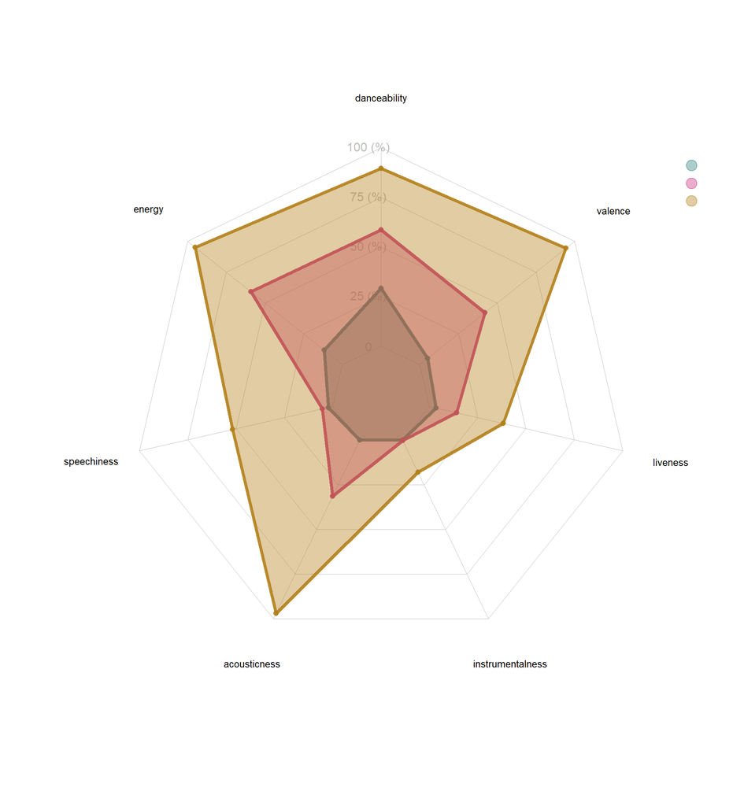

```r
colors_border=c( rgb(0.2,0.5,0.5,0.9), rgb(0.8,0.2,0.5,0.9) , rgb(0.7,0.5,0.1,0.9) )
colors_in=c( rgb(0.2,0.5,0.5,0.4), rgb(0.8,0.2,0.5,0.4) , rgb(0.7,0.5,0.1,0.4) )
radarchart( standard_data  , axistype=1 ,
    #custom polygon
    pcol=colors_border , pfcol=colors_in , plwd=4 , plty=1,
    #custom the grid
    cglcol="grey", cglty=1, axislabcol="grey", caxislabels=seq(0,1,5), cglwd=0.8,
    #custom labels
    vlcex=0.8
    )
legend(x=1.2, y=1, legend = rownames(standard_data[-c(1,2),]), bty = "n", pch=20 , col=colors_in , text.col = "grey", cex=1.2, pt.cex=3)
```

```r
sum_df<-do.call(cbind, lapply(numerical_data, summary))
summary<-rbind(sum_df,numerical_data %>% summarise_if(is.numeric, sd))[c(4,7),]
rownames(summary)<-c("Mean","SD")
summary
```

```
##      track_number danceability    energy      key  loudness      mode
## Mean     9.877301    0.5867423 0.5908896 4.601227 -7.215466 0.8957055
## SD       5.844458    0.1163803 0.1852035 3.302711  2.638172 0.3065841
##      speechiness acousticness instrumentalness   liveness   valence     tempo
## Mean  0.05418957    0.3132342       0.00260274 0.14063742 0.4200933 124.93952
## SD    0.05333396    0.3294357       0.01921601 0.07629626 0.1904104  31.72381
##      time_signature duration_ms
## Mean      3.9877301   237337.60
## SD        0.2937146    38653.41
```

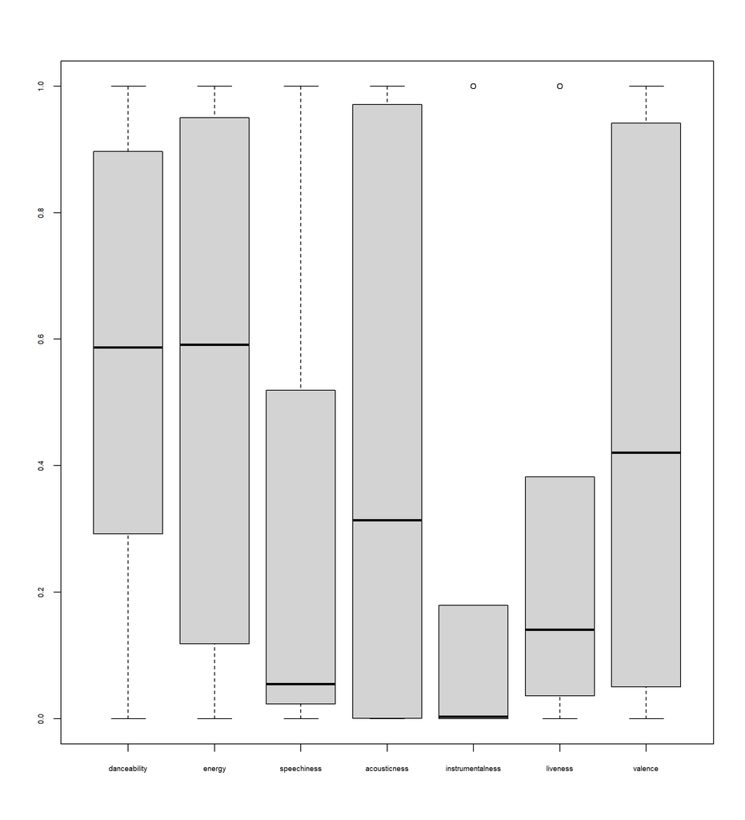

```r
par(cex.axis=.6)
boxplot(standard_data)
```

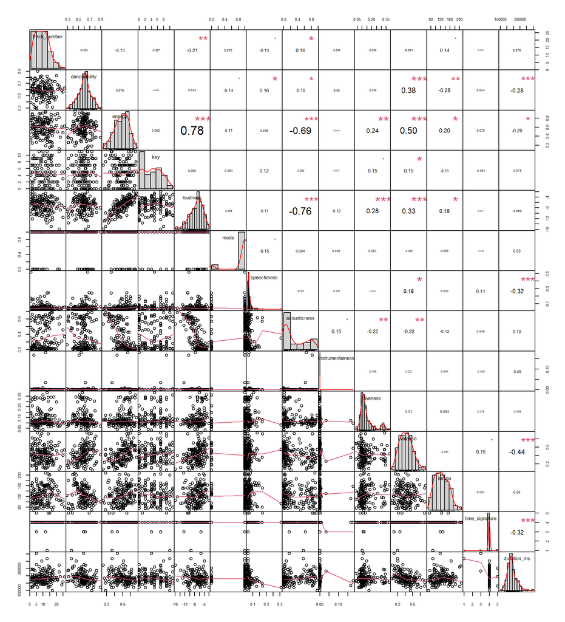

```r
chart.Correlation(numerical_data, histogram = TRUE)
```

1. RadarPlot(Mean Values)
   - Songs has good dancebality, energy, acousticness and valence
   - Speechiness, instrumentalness and liveness are on the lower side
2. Boxplot
   - For Dancebility,energy, acousticness and valence, the plots are tall and indicates quite variability among songs and there doesn’t seem to be having any outliers
   - Liveness and instrumentalness are on the lower side though there are outliers for both. +Speechiness has long upper whisker which means that Speechiness is varied amongst the most positive quartile group
   - Similary dancebility has long lower whisker which means dancebility is varied amongst the least positive quartile range
3. Histogram
   - Dancebility and Duration seems to be normally distributed
   - Energy and Loudness seems skewed to the left
4. Scatterplot matrix- Correlation
   - Energy vs Loudness - High Positive Correlation - 0.78
   - Acousticness vs Loudness - High Negative Correlation - (-0.76)
   - Energy vs Acousticness - High Negative Correlation - (-0.69)
   - Energy Vs Valence - .50 Positive Correlation
   - Other notable correlation
     - Energy vs liveness - 0.24
     - Loudness vs liveness - 0.28
     - Dancebility vs Valence - 0.38
     - Loudness vs Valence - 0.33
     - Dancebility vs Duration_ms - (-0.28)
     - Speechiness vs Duration_ms - (-0.32)
     - Valence vs Duration_ms (- 0.44)
     - Time_signature vs Duration_ms (-0.32)

##### Categorical Data

```r
categorical_analysis
```

```
## # A tibble: 10 x 5
##    col_name              cnt common                      common_pcnt levels
##    <chr>               <int> <chr>                             <dbl> <named lis>
##  1 featuring              11 Bon Iver                          16.7  <tibble [1~
##  2 promotional_release    13 2010-11-08                        14.3  <tibble [1~
##  3 single_release         44 2006-06-19                         2.27 <tibble [4~
##  4 album_name              9 Fearless (Taylor's Version)       16.0  <tibble [9~
##  5 bonus_track             2 FALSE                             88.3  <tibble [2~
##  6 ep                      1 FALSE                            100    <tibble [1~
##  7 explicit                2 FALSE                             93.3  <tibble [2~
##  8 key_mode               19 C major                           15.3  <tibble [1~
##  9 mode_name               2 major                             89.6  <tibble [2~
## 10 track_release          34 2021-04-09                        14.1  <tibble [3~
```

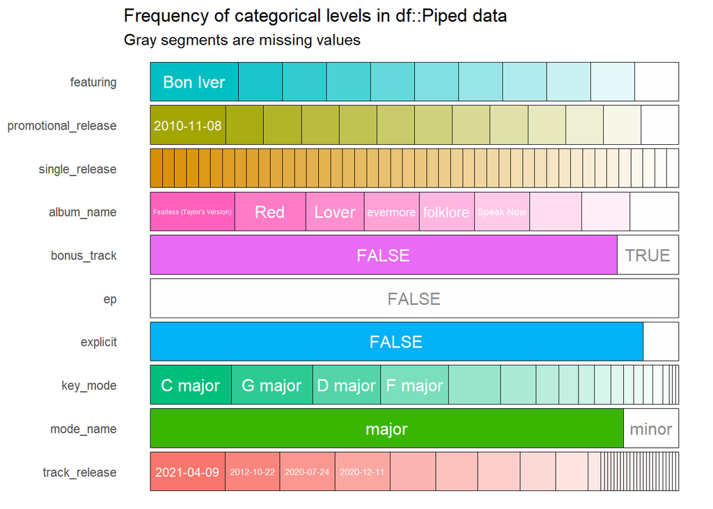

```r
categorical_analysis %>% show_plot()
```

1. Observations
   - Bon Iver is the most featured artist
   - Most promotional_release was in 2010-11-08
   - Most songs are from album Fearless
   - Most releases were on date 2021-04-09
   - Majority doesn’t have bonus track
   - C major, G major, D major and F Major seems dominate her songs
   - Major seems to dominate her music

##### Detailed Lyrical Data Analysis

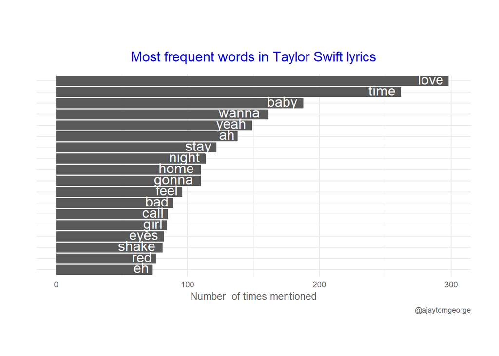

```r
tidy_taylor %>%
  count(word, sort = TRUE) %>%
  #filtering to get only the information we want on the plot
  filter(n > 70,
         word != "di",
         word != "ooh",
         word != "ey")%>%
  ggplot(aes(x = reorder(word, n), y = n))+
  geom_bar(stat="identity")+
  geom_text(aes(label = reorder(word, n)),
            hjust = 1.2,vjust = 0.3, color = "white",
            size = 5)+
  labs(y = "Number  of times mentioned",
       x = NULL,
       title = "Most frequent words in Taylor Swift lyrics",
       caption = "@ajaytomgeorge")+
  coord_flip()+
  ylim(c(0, 300))+ # I didn't want to have the bars covering the whole plotting area
  theme_minimal()+
  #now making more visually appealing
  theme(plot.title = element_text( hjust = 0.5,vjust = 3, color = "blue3", size = 14,  family="Forte"),
        axis.text.y = element_blank(),
        axis.text.x = element_text(size = 8, color = "grey40"),
        axis.title.x = element_text(size = 10, color = "grey40"),
        plot.caption = element_text(size = 7.5, color = "grey40"),
        plot.margin=unit(c(2,1,1.5,1.2),"cm"))
```

1. Word Frequency Plot
   - Love and time seems to dominate other words by a large margin
   - Top 5 words are positive or nuetral

#### Sentiment Analysis

```r
tay_sentiment <- tidy_taylor%>%
  inner_join(get_sentiments("bing"))%>%
  count(Album, Track, sentiment) %>%
  spread(sentiment, n, fill = 0) %>%
  mutate(sentiment = positive - negative)
```

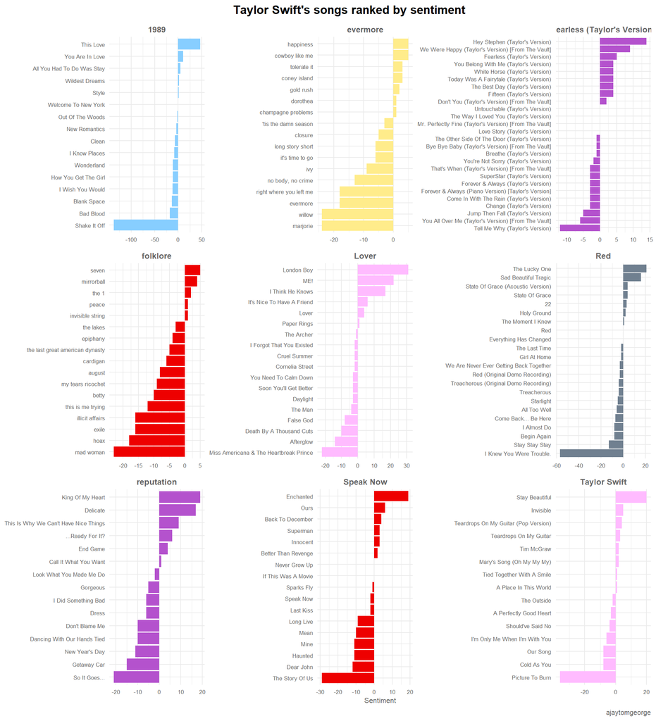

```r
tay_sentiment%>%
  ggplot(aes(reorder(Track, sentiment), sentiment, fill = Album)) +
  geom_col(show.legend = FALSE) +
  facet_wrap(~Album, ncol = 3, scales = "free")+
  scale_fill_manual(values = c("skyblue1", "lightgoldenrod1", "mediumorchid3", "red2", "plum1", "slategray","mediumorchid3", "red2", "plum1"))+
  labs(x = NULL,
       y = "Sentiment",
       title = "Taylor Swift's songs ranked by sentiment",
       caption = "                                                                                                                                    ajaytomgeorge")+
  theme_minimal()+
  theme(plot.title = element_text(size = 13, hjust = 0.4, face = "bold"),
        axis.title.y = element_text(hjust = 0.05, size = 7, color = "grey40", angle = 0),
        axis.title.x =  element_text(size = 8, color = "grey40"),
        axis.text.x = element_text(size = 6.5, color = "grey40"),
        axis.text.y = element_text(size = 6.5, color = "grey40"),
        strip.text = element_text(size = 9, color = "grey40", face = "bold"),
        plot.caption = element_text(size = 7.5, color = "grey40"))+
  coord_flip()
```

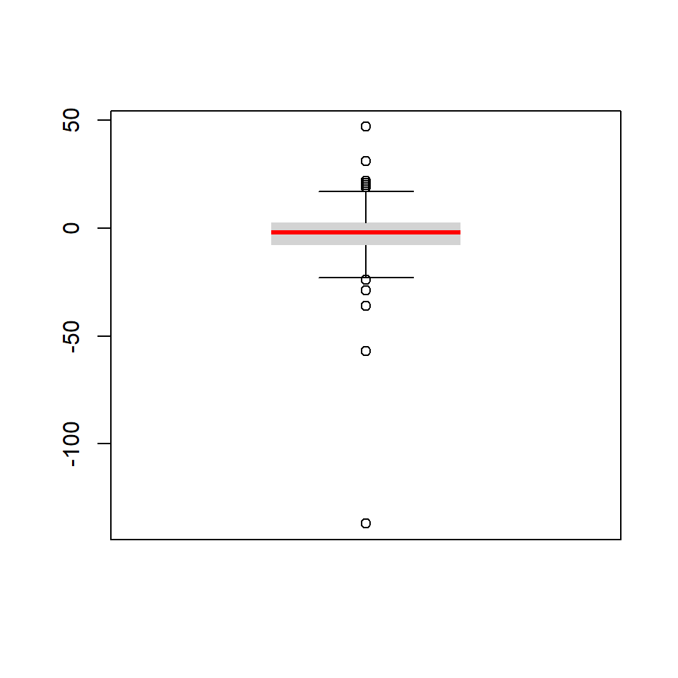

```r
boxplot(tay_sentiment$sentiment,medcol = "red", boxlty = 0, whisklty = 1)
```

1. There is an overall tendency of sentiment of her songs is slighty negative with many outliers in very postive and very negative songs
2. Evermore and Folklore seems to gave negatice sentiment songs